# Curso de Inferencia

Giovany Babativa

Junio 2023

### Distribuciones de probabilidad

#### Distribución normal

Puede usar el siguiente comando `?pnorm` para revisar la ayuda de la función

- Si $X \sim N(\mu = 3, \sigma^2 = 5)$ entonces $P(X > 1)$ se calcula como

```r
1-pnorm(1, mean = 3, sd = sqrt(5))
```

```
## [1] 0.8144533
```

También puede usar

```r
pnorm(1, mean = 3, sd = sqrt(5), lower.tail = FALSE)
```

```
## [1] 0.8144533
```

- Para encontrar $q$ tal que $P(X < q) = 0.2$

```r
qnorm(0.2, mean = 3, sd = sqrt(5), lower.tail = TRUE)
```

```
## [1] 1.118078
```

#### Distribución binomial

Use la ayuda `?pbinom`

Un agente de seguros vende pólizas a cinco personas de la misma edad y que disfrutan de buena salud. Según las tablas actuales, la probabilidad de que una persona en estas condiciones viva 30 años o más es de $2/3$. Calcule la probabilidad de que transcurridos 30 años, vivan:

- Las 5 personas

```r
dbinom(x = 5, size = 5, prob = 2/3)
```

```
## [1] 0.1316872
```

- Al menos 3 personas, $P(X \geq 3) = 1 - P(X < 3)$

```r
1 - pbinom(2, size = 5, prob = 2/3)
```

```
## [1] 0.7901235
```

- Si $p=0.4$ y $n=50$, calcule $P(X = 15)$.
- Si $p=0.4$ y $n=50$, calcule $P(X \leq 15)$.
- Si $p=0.4$ y $n=50$, calcule $P(10 \leq X \leq 15)$.
- Si $p=0.4$ y $n=50$, calcule $q$ tal que $P(X \leq q) = 0.561$.

```r
qbinom(p = 0.561, size = 50, prob = 0.4)
```

```
## [1] 20
```

### Manejo de datos

- Paso 1. Limpie su entorno
- Paso 2. Defina un directorio de trabajo.
- Paso 3. Cargue los paquetes necesarios.
- Paso … Ciclo de analítica.

#### Exploración de conjuntos de datos

Asegúrese de tener instalados los siguientes paquetes:

```r
library(tidyverse)
library(skimr)
library(nycflights13)
library(knitr)
```

Cargue el conjunto de datos `flights`, revise la ayuda usando `?flights` y explore

- Use la función `View()` del entorno `R`.
- Use la función `glimpse()` del entorno `tidyverse`.

```r
glimpse(flights)
```

```
## Rows: 336,776
## Columns: 19
## $ year           <int> 2013, 2013, 2013, 2013, 2013, 2013, 2013, 2013, 2013, 2…
## $ month          <int> 1, 1, 1, 1, 1, 1, 1, 1, 1, 1, 1, 1, 1, 1, 1, 1, 1, 1, 1…
## $ day            <int> 1, 1, 1, 1, 1, 1, 1, 1, 1, 1, 1, 1, 1, 1, 1, 1, 1, 1, 1…
## $ dep_time       <int> 517, 533, 542, 544, 554, 554, 555, 557, 557, 558, 558, …
## $ sched_dep_time <int> 515, 529, 540, 545, 600, 558, 600, 600, 600, 600, 600, …
## $ dep_delay      <dbl> 2, 4, 2, -1, -6, -4, -5, -3, -3, -2, -2, -2, -2, -2, -1…
## $ arr_time       <int> 830, 850, 923, 1004, 812, 740, 913, 709, 838, 753, 849,…
## $ sched_arr_time <int> 819, 830, 850, 1022, 837, 728, 854, 723, 846, 745, 851,…
## $ arr_delay      <dbl> 11, 20, 33, -18, -25, 12, 19, -14, -8, 8, -2, -3, 7, -1…
## $ carrier        <chr> "UA", "UA", "AA", "B6", "DL", "UA", "B6", "EV", "B6", "…
## $ flight         <int> 1545, 1714, 1141, 725, 461, 1696, 507, 5708, 79, 301, 4…
## $ tailnum        <chr> "N14228", "N24211", "N619AA", "N804JB", "N668DN", "N394…
## $ origin         <chr> "EWR", "LGA", "JFK", "JFK", "LGA", "EWR", "EWR", "LGA",…
## $ dest           <chr> "IAH", "IAH", "MIA", "BQN", "ATL", "ORD", "FLL", "IAD",…
## $ air_time       <dbl> 227, 227, 160, 183, 116, 150, 158, 53, 140, 138, 149, 1…
## $ distance       <dbl> 1400, 1416, 1089, 1576, 762, 719, 1065, 229, 944, 733, …
## $ hour           <dbl> 5, 5, 5, 5, 6, 5, 6, 6, 6, 6, 6, 6, 6, 6, 6, 5, 6, 6, 6…
## $ minute         <dbl> 15, 29, 40, 45, 0, 58, 0, 0, 0, 0, 0, 0, 0, 0, 0, 59, 0…
## $ time_hour      <dttm> 2013-01-01 05:00:00, 2013-01-01 05:00:00, 2013-01-01 0…
```

- Use la función `kable()` del paquete `knitr` para imprimir los primeros 5 registros del marco de datos.

```r
knitr::kable(flights[1:5,])
```

| year | month | day | dep_time | sched_dep_time | dep_delay | arr_time | sched_arr_time | arr_delay | carrier | flight | tailnum | origin | dest | air_time | distance | hour | minute | time_hour |
| --- | --- | --- | --- | --- | --- | --- | --- | --- | --- | --- | --- | --- | --- | --- | --- | --- | --- | --- |
| 2013 | 1 | 1 | 517 | 515 | 2 | 830 | 819 | 11 | UA | 1545 | N14228 | EWR | IAH | 227 | 1400 | 5 | 15 | 2013-01-01 05:00:00 |
| 2013 | 1 | 1 | 533 | 529 | 4 | 850 | 830 | 20 | UA | 1714 | N24211 | LGA | IAH | 227 | 1416 | 5 | 29 | 2013-01-01 05:00:00 |
| 2013 | 1 | 1 | 542 | 540 | 2 | 923 | 850 | 33 | AA | 1141 | N619AA | JFK | MIA | 160 | 1089 | 5 | 40 | 2013-01-01 05:00:00 |
| 2013 | 1 | 1 | 544 | 545 | -1 | 1004 | 1022 | -18 | B6 | 725 | N804JB | JFK | BQN | 183 | 1576 | 5 | 45 | 2013-01-01 05:00:00 |
| 2013 | 1 | 1 | 554 | 600 | -6 | 812 | 837 | -25 | DL | 461 | N668DN | LGA | ATL | 116 | 762 | 6 | 0 | 2013-01-01 06:00:00 |

- Use la función `skim()` del paquete `skimr` sobre la consola. Cargue el conjunto de datos y el paquete `nycflights13`.

### Bonus

Además de paquetes que son útiles en todo en proceso de *data wrangling* como los contenidos en `tidyverse`, también hay otros paquetes que pueden ser de utilidad en esta etapa como lo son `skimr`, `summarytools`, `janitor`, `VIM` o `naniar`.

```r
library(summarytools)
```

La función `dfSummary` del paquete `summarytools`, que permite realizar las tablas de frecuencias para todas las variables del conjunto de datos de entrada.

```r
print(summarytools::dfSummary(flights,
                              round.digits=1,
                              plain.ascii = F ,
                              style = "grid",
                              max.distinct.values=10,
                              max.string.width=30,
                              graph.magnif = 0.75,
                              valid.col = F,
                              tmp.img.dir = ".",
                              method = 'viewer'),
      method = 'render')
```

```
## temporary images written to 'G:\Mi unidad\Mis Cursos\4. Inferencia Estadística\Inf\Inf\R'
```

Data Frame Summary

flights

**Dimensions**: 336776 x 19  
**Duplicates**: 0

| **No** | **Variable** | **Stats / Values** | **Freqs (% of Valid)** | **Graph** | **Missing** |
| --- | --- | --- | --- | --- | --- |
| 1 | year [integer] | 1 distinct value | 2013 : 336776 ( 100.0% ) |  | 0 (0.0%) |
| 2 | month [integer] | Mean (sd) : 6.5 (3.4) min ≤ med ≤ max: 1 ≤ 7 ≤ 12 IQR (CV) : 6 (0.5) | 12 distinct values |  | 0 (0.0%) |
| 3 | day [integer] | Mean (sd) : 15.7 (8.8) min ≤ med ≤ max: 1 ≤ 16 ≤ 31 IQR (CV) : 15 (0.6) | 31 distinct values |  | 0 (0.0%) |
| 4 | dep_time [integer] | Mean (sd) : 1349.1 (488.3) min ≤ med ≤ max: 1 ≤ 1401 ≤ 2400 IQR (CV) : 837 (0.4) | 1318 distinct values |  | 8255 (2.5%) |
| 5 | sched_dep_time [integer] | Mean (sd) : 1344.3 (467.3) min ≤ med ≤ max: 106 ≤ 1359 ≤ 2359 IQR (CV) : 823 (0.3) | 1021 distinct values |  | 0 (0.0%) |
| 6 | dep_delay [numeric] | Mean (sd) : 12.6 (40.2) min ≤ med ≤ max: -43 ≤ -2 ≤ 1301 IQR (CV) : 16 (3.2) | 527 distinct values |  | 8255 (2.5%) |
| 7 | arr_time [integer] | Mean (sd) : 1502.1 (533.3) min ≤ med ≤ max: 1 ≤ 1535 ≤ 2400 IQR (CV) : 836 (0.4) | 1411 distinct values |  | 8713 (2.6%) |
| 8 | sched_arr_time [integer] | Mean (sd) : 1536.4 (497.5) min ≤ med ≤ max: 1 ≤ 1556 ≤ 2359 IQR (CV) : 821 (0.3) | 1163 distinct values |  | 0 (0.0%) |
| 9 | arr_delay [numeric] | Mean (sd) : 6.9 (44.6) min ≤ med ≤ max: -86 ≤ -5 ≤ 1272 IQR (CV) : 31 (6.5) | 577 distinct values |  | 9430 (2.8%) |
| 10 | carrier [character] | 1. UA 2. B6 3. EV 4. DL 5. AA 6. MQ 7. US 8. 9E 9. WN 10. VX [ 6 others ] | 58665 ( 17.4% ) 54635 ( 16.2% ) 54173 ( 16.1% ) 48110 ( 14.3% ) 32729 ( 9.7% ) 26397 ( 7.8% ) 20536 ( 6.1% ) 18460 ( 5.5% ) 12275 ( 3.6% ) 5162 ( 1.5% ) 5634 ( 1.7% ) |  | 0 (0.0%) |
| 11 | flight [integer] | Mean (sd) : 1971.9 (1632.5) min ≤ med ≤ max: 1 ≤ 1496 ≤ 8500 IQR (CV) : 2912 (0.8) | 3844 distinct values |  | 0 (0.0%) |
| 12 | tailnum [character] | 1. N725MQ 2. N722MQ 3. N723MQ 4. N711MQ 5. N713MQ 6. N258JB 7. N298JB 8. N353JB 9. N351JB 10. N735MQ [ 4033 others ] | 575 ( 0.2% ) 513 ( 0.2% ) 507 ( 0.2% ) 486 ( 0.1% ) 483 ( 0.1% ) 427 ( 0.1% ) 407 ( 0.1% ) 404 ( 0.1% ) 402 ( 0.1% ) 396 ( 0.1% ) 329664 ( 98.6% ) |  | 2512 (0.7%) |
| 13 | origin [character] | 1. EWR 2. JFK 3. LGA | 120835 ( 35.9% ) 111279 ( 33.0% ) 104662 ( 31.1% ) |  | 0 (0.0%) |
| 14 | dest [character] | 1. ORD 2. ATL 3. LAX 4. BOS 5. MCO 6. CLT 7. SFO 8. FLL 9. MIA 10. DCA [ 95 others ] | 17283 ( 5.1% ) 17215 ( 5.1% ) 16174 ( 4.8% ) 15508 ( 4.6% ) 14082 ( 4.2% ) 14064 ( 4.2% ) 13331 ( 4.0% ) 12055 ( 3.6% ) 11728 ( 3.5% ) 9705 ( 2.9% ) 195631 ( 58.1% ) |  | 0 (0.0%) |
| 15 | air_time [numeric] | Mean (sd) : 150.7 (93.7) min ≤ med ≤ max: 20 ≤ 129 ≤ 695 IQR (CV) : 110 (0.6) | 509 distinct values |  | 9430 (2.8%) |
| 16 | distance [numeric] | Mean (sd) : 1039.9 (733.2) min ≤ med ≤ max: 17 ≤ 872 ≤ 4983 IQR (CV) : 887 (0.7) | 214 distinct values |  | 0 (0.0%) |
| 17 | hour [numeric] | Mean (sd) : 13.2 (4.7) min ≤ med ≤ max: 1 ≤ 13 ≤ 23 IQR (CV) : 8 (0.4) | 20 distinct values |  | 0 (0.0%) |
| 18 | minute [numeric] | Mean (sd) : 26.2 (19.3) min ≤ med ≤ max: 0 ≤ 29 ≤ 59 IQR (CV) : 36 (0.7) | 60 distinct values |  | 0 (0.0%) |
| 19 | time_hour [POSIXct, POSIXt] | min : 2013-01-01 05:00:00 med : 2013-07-03 10:00:00 max : 2013-12-31 23:00:00 range : 11m 30d 18H 0M 0S | 6936 distinct values |  | 0 (0.0%) |

Generated by summarytools 1.0.1 ([R](https://www.r-project.org/) version 4.2.2)  
2023-06-23

### Visualización de los datos

Algunos de los tipos de gráficos más importantes son:

- Dispersión de puntos
- Líneas
- Histogramas
- Diagramas de cajas
- Gráficas de barras

#### Dispersión de puntos

- Haga una tabla de frecuencias de la variable `carrier`
- Seleccione los vuelos hacía Alaska `carrier == "AS"`
- Realice el gráfico de dispersión entre las variables de salida y llegada tarde.

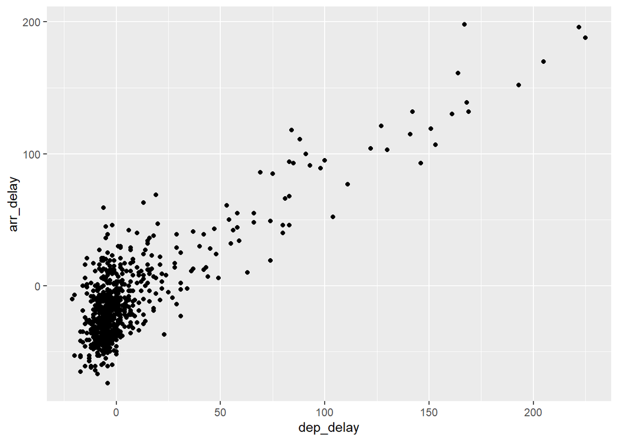

```r
flights |>
  filter(carrier == "AS") |>
ggplot(aes(x = dep_delay, y = arr_delay)) +
  geom_point() #Agregue alpha = 0.2 dentro de la geometria
```

#### Líneas

- Use el marco de datos `weather` del paquete `nycflights13`.
- Explore mediante las funciones `View()` o `glimpse()`.
- Puede conocer el contexto de los datos con `?weather`.
- La variable `temp` registra la temperatura en Fahrenheit para los tres aeropuertos más grandes de NY: Newark (EWR), John F. Kennedy (JFK) y La Guardia (LGA). Considere las temperaturas de los primeros 15 días de enero.
- Realice el gráfico de líneas

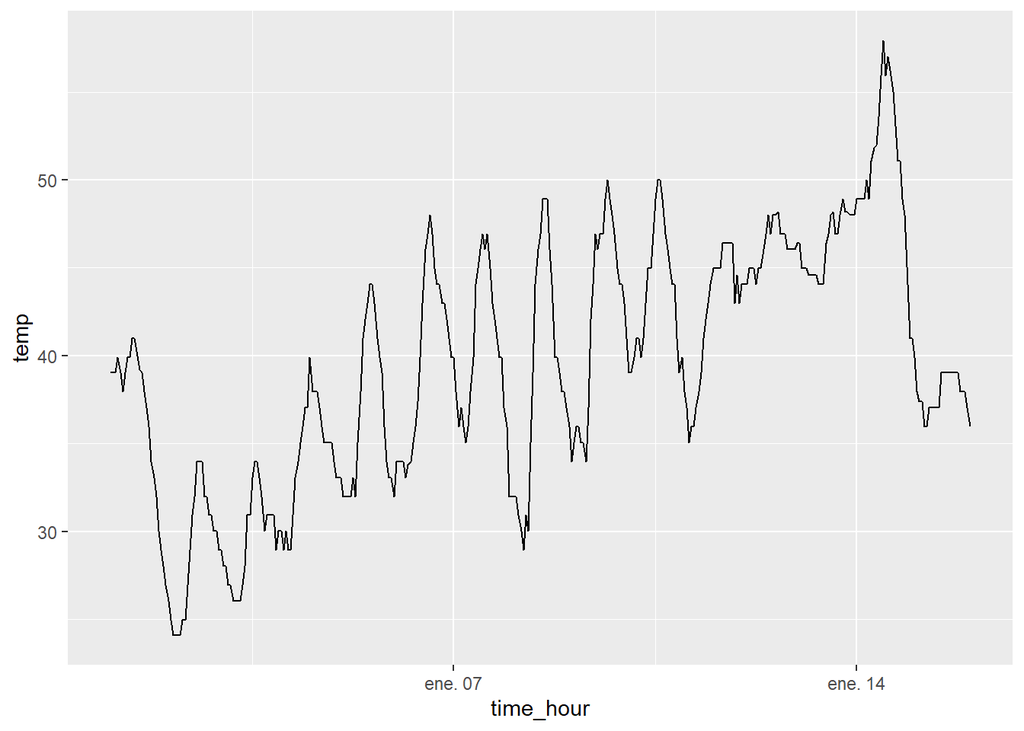

```r
enero <- weather |>
         filter(origin == "EWR" , month == 1 , day <= 15)

enero |>
      ggplot(aes(x = time_hour, y = temp)) +
      geom_line()
```

#### Histogramas

- Use la variable `temp` del conjunto de datos `weather`.
- Realice un histograma que presente la distribución de los datos.
- Use una geometría de densidad.

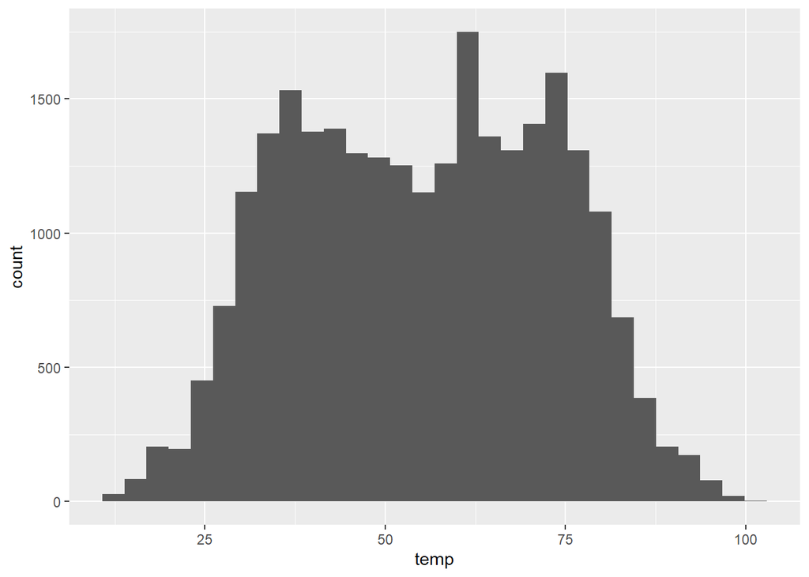

```r
weather |>
  ggplot(aes(x = temp)) +
  geom_histogram()
```

- Ahora agregamos la opción `bins`, donde cada `bins` reprenta un rango de valores. Para ver opciones de colores puede ejecutar `colors()`.
- Use `binwidth` para definir un ancho de banda de 10.
- Asigne cada gráfico en un objeto e imprima los dos juntos usando el paquete `patchwork`.

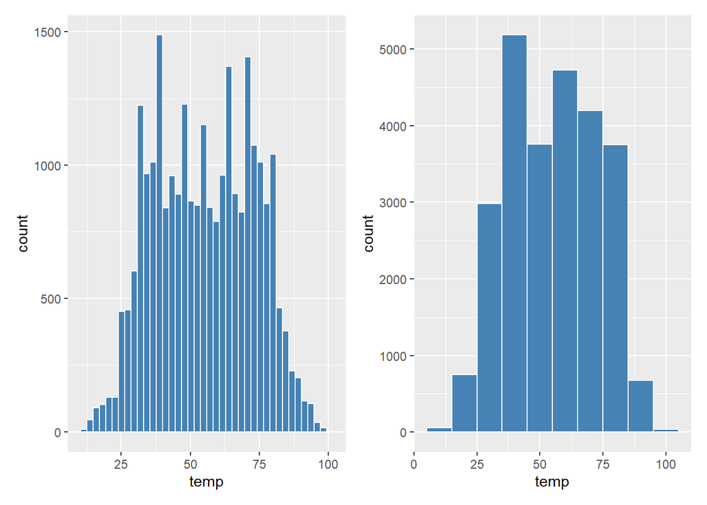

```r
b40 <- weather |>
  ggplot(aes(x = temp)) +
  geom_histogram(color = "white", bins = 40, fill = "steelblue")

ab10 <- weather |>
  ggplot(aes(x = temp)) +
  geom_histogram(color = "white", binwidth = 10, fill = "steelblue")

b40 | ab10
```

- Incluya Facetas por mes

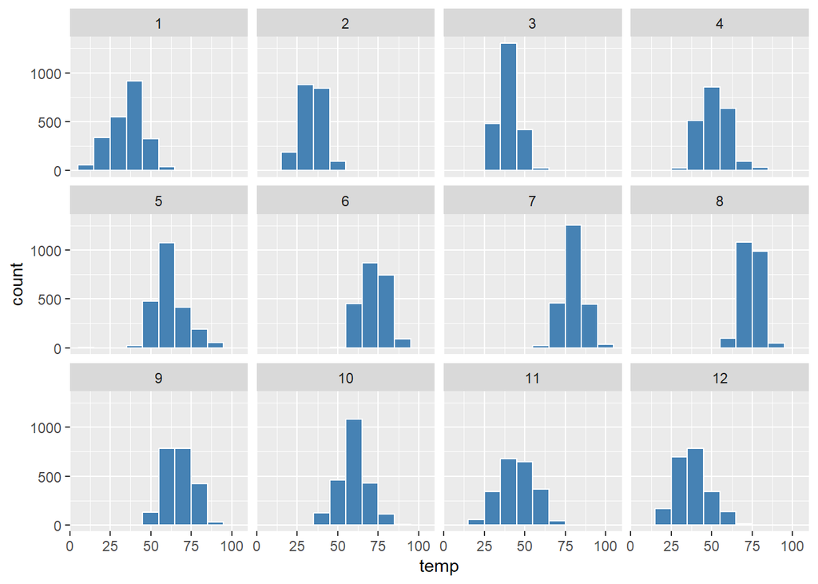

```r
weather |>
  ggplot(aes(x = temp)) +
  geom_histogram(color = "white", binwidth = 10, fill = "steelblue") +
  facet_wrap(~ month)
```

#### Diagramas de cajas

- Use el conjunto de datos `weather` y describa la temperatura de cada mes mediante un boxplot.

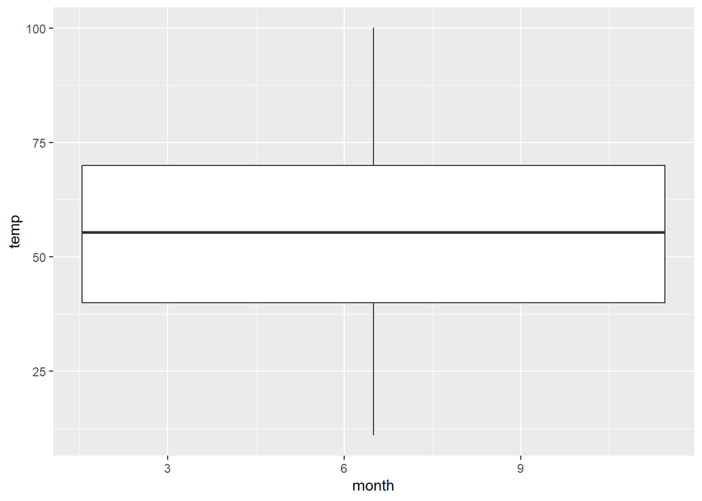

```r
weather |>
ggplot(aes(x = month, y = temp)) +
  geom_boxplot() ### por qué solo sale un boxplot glimpse
```

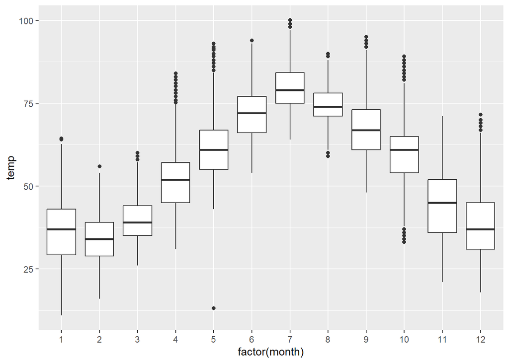

```r
weather |>
ggplot(aes(x = factor(month), y = temp)) +
  geom_boxplot() ### por qué solo sale un boxplot glimpse
```